# Visualizing OPUS binary files and DPT files in R

Adrianne Seiden

2025-08-05

[source](https://spectral-cockpit.github.io/opusreader2/articles/opusreader2_introduction.html)

# Reading OPUS files

## Plots & Metadata

#### Spectrum 1 : DRIFTS_pot001_13Cwheat_wk0_root_250725_corr.0

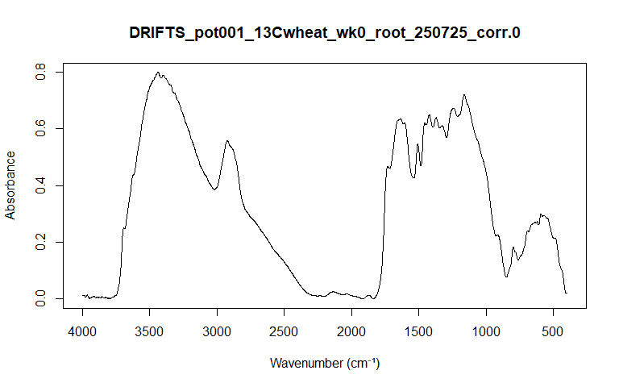

Metadata

| Parameter | Value |
| --- | --- |
| File Name | DRIFTS_pot001_13Cwheat_wk0_root_250725_corr.0 |
| Timestamp | 2025-07-25 20:18:39 GMT-7 |
| Max Y | 0.799607157707214 |
| Min Y | -0.0012896629050374 |
| Aperture Setting | 6 mm |
| Scanner Velocity | 10.0S |
| Result Spectrum | AB |
| Resolution | 4 |
| Sample Scans | 400 |
| End Frequency | 400 |
| Start Frequency | 4000 |
| Duration | 364.56884765625 |
| Experiment (method) | SALK_soils_method.xpm |

#### Spectrum 2 : DRIFTS_pot030_13Csoy_wk10_root_250725_corr.0

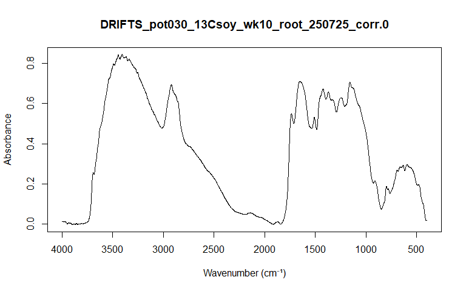

Metadata

| Parameter | Value |
| --- | --- |
| File Name | DRIFTS_pot030_13Csoy_wk10_root_250725_corr.0 |
| Timestamp | 2025-07-25 20:21:37 GMT-7 |
| Max Y | 0.843558788299561 |
| Min Y | -0.00326710939407349 |
| Aperture Setting | 6 mm |
| Scanner Velocity | 10.0S |
| Result Spectrum | AB |
| Resolution | 4 |
| Sample Scans | 400 |
| End Frequency | 400 |
| Start Frequency | 4000 |
| Duration | 364.56689453125 |
| Experiment (method) | SALK_soils_method.xpm |

#### Spectrum 3 : DRIFTS_pot032_13Cwheat_wk0_root_250725_corr.0

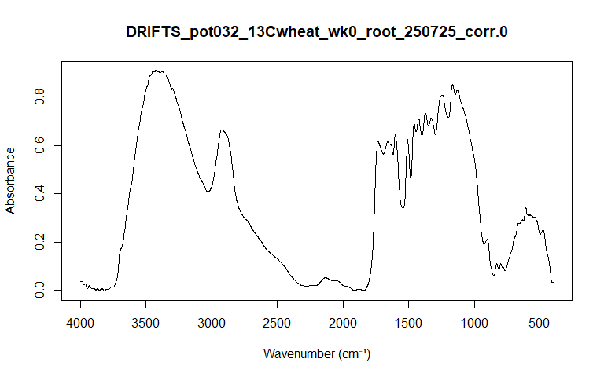

Metadata

| Parameter | Value |
| --- | --- |
| File Name | DRIFTS_pot032_13Cwheat_wk0_root_250725_corr.0 |
| Timestamp | 2025-07-25 20:22:45 GMT-7 |
| Max Y | 0.909599244594574 |
| Min Y | -0.00415003532543778 |
| Aperture Setting | 6 mm |
| Scanner Velocity | 10.0S |
| Result Spectrum | AB |
| Resolution | 4 |
| Sample Scans | 400 |
| End Frequency | 400 |
| Start Frequency | 4000 |
| Duration | 364.56982421875 |
| Experiment (method) | SALK_soils_method.xpm |

#### Spectrum 4 : DRIFTS_pot047_13Crice_wk0_root_250725_corr.0

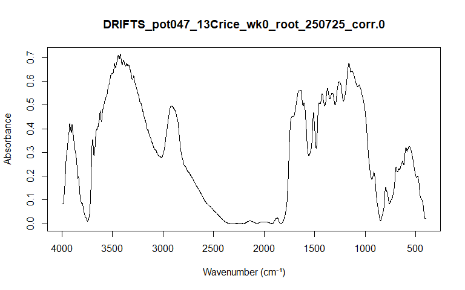

Metadata

| Parameter | Value |
| --- | --- |
| File Name | DRIFTS_pot047_13Crice_wk0_root_250725_corr.0 |
| Timestamp | 2025-07-25 20:23:56 GMT-7 |
| Max Y | 0.712926685810089 |
| Min Y | -0.00133463030215353 |
| Aperture Setting | 6 mm |
| Scanner Velocity | 10.0S |
| Result Spectrum | AB |
| Resolution | 4 |
| Sample Scans | 400 |
| End Frequency | 400 |
| Start Frequency | 4000 |
| Duration | 364.56591796875 |
| Experiment (method) | SALK_soils_method.xpm |

#### Spectrum 5 : DRIFTS_pot053_13Cwheat_wk10_root_250725_corr.0

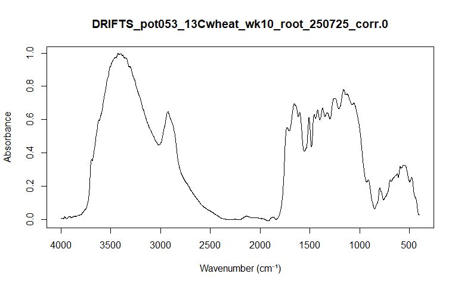

Metadata

| Parameter | Value |
| --- | --- |
| File Name | DRIFTS_pot053_13Cwheat_wk10_root_250725_corr.0 |
| Timestamp | 2025-07-25 20:24:39 GMT-7 |
| Max Y | 0.997280716896057 |
| Min Y | -0.00962971057742834 |
| Aperture Setting | 6 mm |
| Scanner Velocity | 10.0S |
| Result Spectrum | AB |
| Resolution | 4 |
| Sample Scans | 400 |
| End Frequency | 400 |
| Start Frequency | 4000 |
| Duration | 364.56591796875 |
| Experiment (method) | SALK_soils_method.xpm |

#### Spectrum 6 : DRIFTS_pot055_13Crice_wk10_root_250725_corr.0

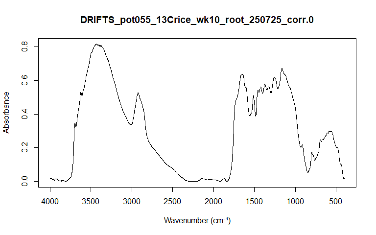

Metadata

| Parameter | Value |
| --- | --- |
| File Name | DRIFTS_pot055_13Crice_wk10_root_250725_corr.0 |
| Timestamp | 2025-07-25 20:26:35 GMT-7 |
| Max Y | 0.816974341869354 |
| Min Y | -0.00123318459372967 |
| Aperture Setting | 6 mm |
| Scanner Velocity | 10.0S |
| Result Spectrum | AB |
| Resolution | 4 |
| Sample Scans | 400 |
| End Frequency | 400 |
| Start Frequency | 4000 |
| Duration | 364.56689453125 |
| Experiment (method) | SALK_soils_method.xpm |

#### Spectrum 7 : DRIFTS_pot055qmark_13Crice_wk10_root_250725_corr.0

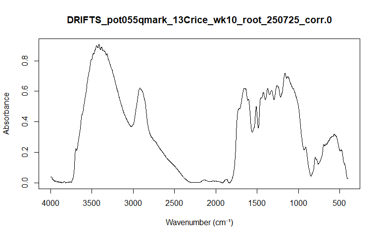

Metadata

| Parameter | Value |
| --- | --- |
| File Name | DRIFTS_pot055qmark_13Crice_wk10_root_250725_corr.0 |
| Timestamp | 2025-07-25 20:25:51 GMT-7 |
| Max Y | 0.907369911670685 |
| Min Y | -0.00234174402430654 |
| Aperture Setting | 6 mm |
| Scanner Velocity | 10.0S |
| Result Spectrum | AB |
| Resolution | 4 |
| Sample Scans | 400 |
| End Frequency | 400 |
| Start Frequency | 4000 |
| Duration | 364.56591796875 |
| Experiment (method) | SALK_soils_method.xpm |

#### Spectrum 8 : DRIFTS_pot062_13Csoy_wk0_root_250725_corr.0

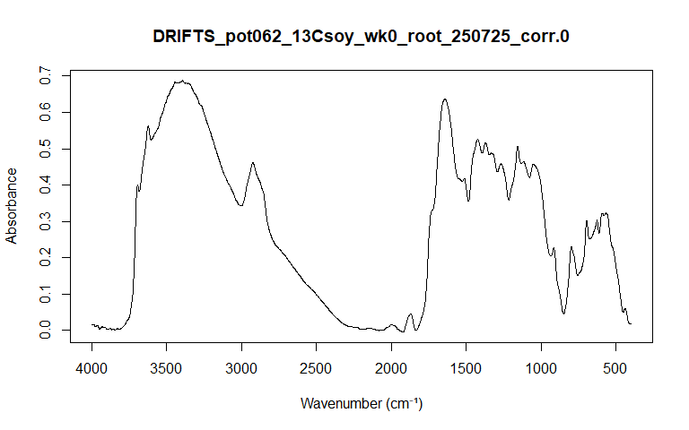

Metadata

| Parameter | Value |
| --- | --- |
| File Name | DRIFTS_pot062_13Csoy_wk0_root_250725_corr.0 |
| Timestamp | 2025-07-25 20:27:28 GMT-7 |
| Max Y | 0.687717080116272 |
| Min Y | -0.00538174575194716 |
| Aperture Setting | 6 mm |
| Scanner Velocity | 10.0S |
| Result Spectrum | AB |
| Resolution | 4 |
| Sample Scans | 400 |
| End Frequency | 400 |
| Start Frequency | 4000 |
| Duration | 364.56884765625 |
| Experiment (method) | SALK_soils_method.xpm |

#### Spectrum 9 : DRIFTS_pot079_13Crice_wk0_root_250725_corr.0

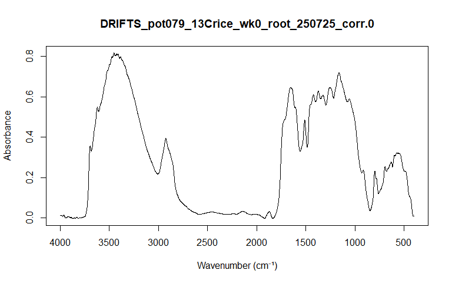

Metadata

| Parameter | Value |
| --- | --- |
| File Name | DRIFTS_pot079_13Crice_wk0_root_250725_corr.0 |
| Timestamp | 2025-07-25 20:28:00 GMT-7 |
| Max Y | 0.816869914531708 |
| Min Y | -0.00257659493945539 |
| Aperture Setting | 6 mm |
| Scanner Velocity | 10.0S |
| Result Spectrum | AB |
| Resolution | 4 |
| Sample Scans | 400 |
| End Frequency | 400 |
| Start Frequency | 4000 |
| Duration | 364.56787109375 |
| Experiment (method) | SALK_soils_method.xpm |

#### Spectrum 10 : DRIFTS_pot080_13Csoy_wk10_root_250725_corr.0

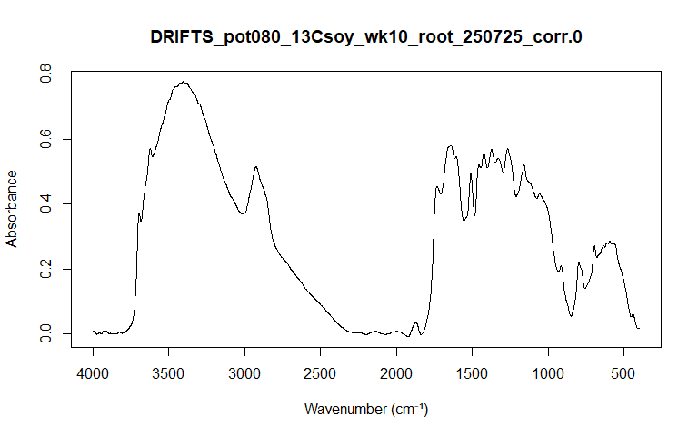

Metadata

| Parameter | Value |
| --- | --- |
| File Name | DRIFTS_pot080_13Csoy_wk10_root_250725_corr.0 |
| Timestamp | 2025-07-25 20:28:56 GMT-7 |
| Max Y | 0.77625048160553 |
| Min Y | -0.00814440380781889 |
| Aperture Setting | 6 mm |
| Scanner Velocity | 10.0S |
| Result Spectrum | AB |
| Resolution | 4 |
| Sample Scans | 400 |
| End Frequency | 400 |
| Start Frequency | 4000 |
| Duration | 364.56689453125 |
| Experiment (method) | SALK_soils_method.xpm |

#### Spectrum 11 : DRIFTS_pot094_13Csoy_wk10_root_250725_corr.0

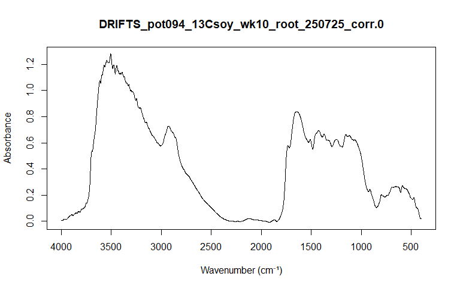

Metadata

| Parameter | Value |
| --- | --- |
| File Name | DRIFTS_pot094_13Csoy_wk10_root_250725_corr.0 |
| Timestamp | 2025-07-25 20:29:09 GMT-7 |
| Max Y | 1.27848649024963 |
| Min Y | -0.00875786785036325 |
| Aperture Setting | 6 mm |
| Scanner Velocity | 10.0S |
| Result Spectrum | AB |
| Resolution | 4 |
| Sample Scans | 400 |
| End Frequency | 400 |
| Start Frequency | 4000 |
| Duration | 364.56689453125 |
| Experiment (method) | SALK_soils_method.xpm |

#### Spectrum 12 : DRIFTS_pot094_13Csoy_wk10_soil_250630_corr.0

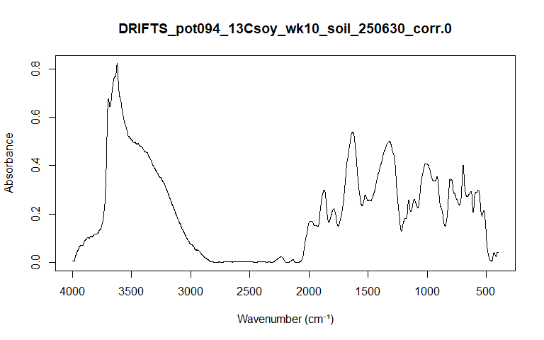

Metadata

| Parameter | Value |
| --- | --- |
| File Name | DRIFTS_pot094_13Csoy_wk10_soil_250630_corr.0 |
| Timestamp | 2025-07-25 20:46:03 GMT-7 |
| Max Y | 0.821687042713165 |
| Min Y | -0.00153941253665835 |
| Aperture Setting | 6 mm |
| Scanner Velocity | 10.0S |
| Result Spectrum | AB |
| Resolution | 4 |
| Sample Scans | 400 |
| End Frequency | 400 |
| Start Frequency | 4000 |
| Duration | 364.454833984375 |
| Experiment (method) | SALK_soils_method.xpm |

#### Spectrum 13 : DRIFTS_pot103_13Crice_wk0_root_recNMR_250725_corr.0

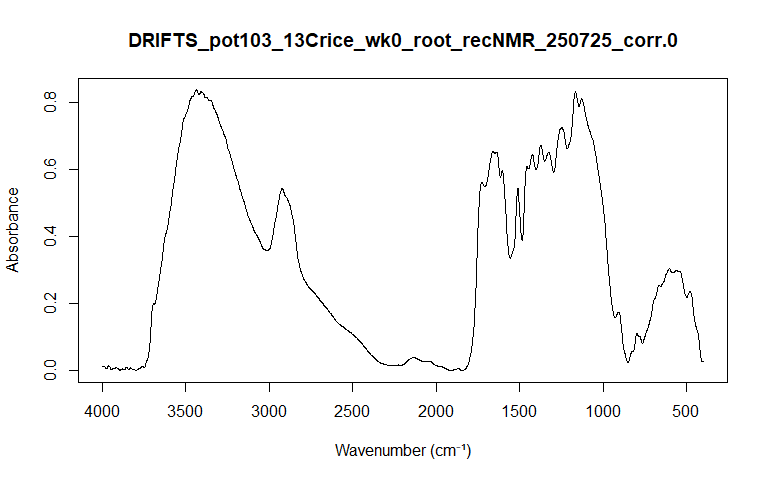

Metadata

| Parameter | Value |
| --- | --- |
| File Name | DRIFTS_pot103_13Crice_wk0_root_recNMR_250725_corr.0 |
| Timestamp | 2025-07-25 20:30:32 GMT-7 |
| Max Y | 0.836920917034149 |
| Min Y | -0.00138377456460148 |
| Aperture Setting | 6 mm |
| Scanner Velocity | 10.0S |
| Result Spectrum | AB |
| Resolution | 4 |
| Sample Scans | 400 |
| End Frequency | 400 |
| Start Frequency | 4000 |
| Duration | 364.56982421875 |
| Experiment (method) | SALK_soils_method.xpm |

#### Spectrum 14 : DRIFTS_pot103_13Crice_wk0_root_vial1_250725_corr.0

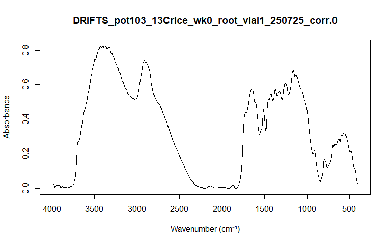

Metadata

| Parameter | Value |
| --- | --- |
| File Name | DRIFTS_pot103_13Crice_wk0_root_vial1_250725_corr.0 |
| Timestamp | 2025-07-25 20:30:55 GMT-7 |
| Max Y | 0.826825261116028 |
| Min Y | -0.000596170837525278 |
| Aperture Setting | 6 mm |
| Scanner Velocity | 10.0S |
| Result Spectrum | AB |
| Resolution | 4 |
| Sample Scans | 400 |
| End Frequency | 400 |
| Start Frequency | 4000 |
| Duration | 364.56787109375 |
| Experiment (method) | SALK_soils_method.xpm |

#### Spectrum 15 : DRIFTS_pot103_13Crice_wk0_root_vial2_250725_corr.0

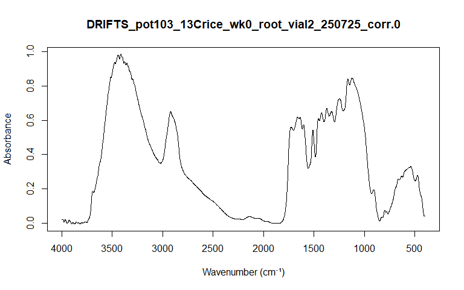

Metadata

| Parameter | Value |
| --- | --- |
| File Name | DRIFTS_pot103_13Crice_wk0_root_vial2_250725_corr.0 |
| Timestamp | 2025-07-25 20:31:26 GMT-7 |
| Max Y | 0.984898567199707 |
| Min Y | -0.00565983727574348 |
| Aperture Setting | 6 mm |
| Scanner Velocity | 10.0S |
| Result Spectrum | AB |
| Resolution | 4 |
| Sample Scans | 400 |
| End Frequency | 400 |
| Start Frequency | 4000 |
| Duration | 364.56591796875 |
| Experiment (method) | SALK_soils_method.xpm |

#### Spectrum 16 : DRIFTS_pot103_13Crice_wk0_root_vial3_250725_corr.0

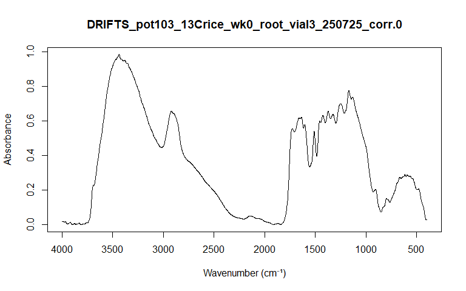

Metadata

| Parameter | Value |
| --- | --- |
| File Name | DRIFTS_pot103_13Crice_wk0_root_vial3_250725_corr.0 |
| Timestamp | 2025-07-25 20:31:46 GMT-7 |
| Max Y | 0.983739078044891 |
| Min Y | -0.0026757272426039 |
| Aperture Setting | 6 mm |
| Scanner Velocity | 10.0S |
| Result Spectrum | AB |
| Resolution | 4 |
| Sample Scans | 400 |
| End Frequency | 400 |
| Start Frequency | 4000 |
| Duration | 364.56591796875 |
| Experiment (method) | SALK_soils_method.xpm |

#### Spectrum 17 : DRIFTS_pot107_12Crice_wk0_root_really13_250725_corr.0

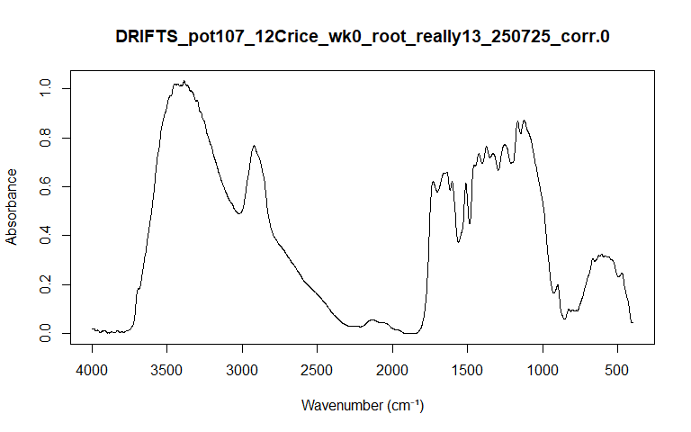

Metadata

| Parameter | Value |
| --- | --- |
| File Name | DRIFTS_pot107_12Crice_wk0_root_really13_250725_corr.0 |
| Timestamp | 2025-07-25 20:32:00 GMT-7 |
| Max Y | 1.03206670284271 |
| Min Y | -0.00172662467230111 |
| Aperture Setting | 6 mm |
| Scanner Velocity | 10.0S |
| Result Spectrum | AB |
| Resolution | 4 |
| Sample Scans | 400 |
| End Frequency | 400 |
| Start Frequency | 4000 |
| Duration | 364.56591796875 |
| Experiment (method) | SALK_soils_method.xpm |

## Stacking multiple spectra

### Stacking re-runs

This code looks for files with the same sample number and stacks their spectra.

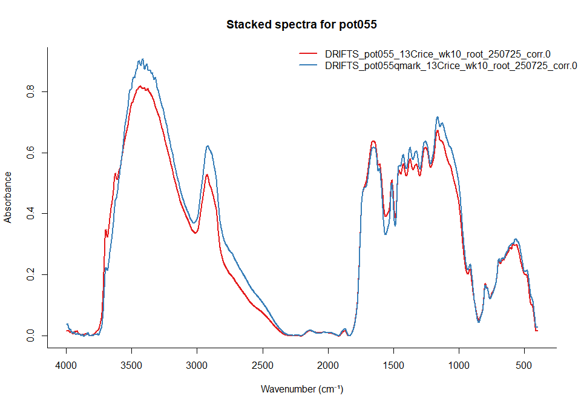

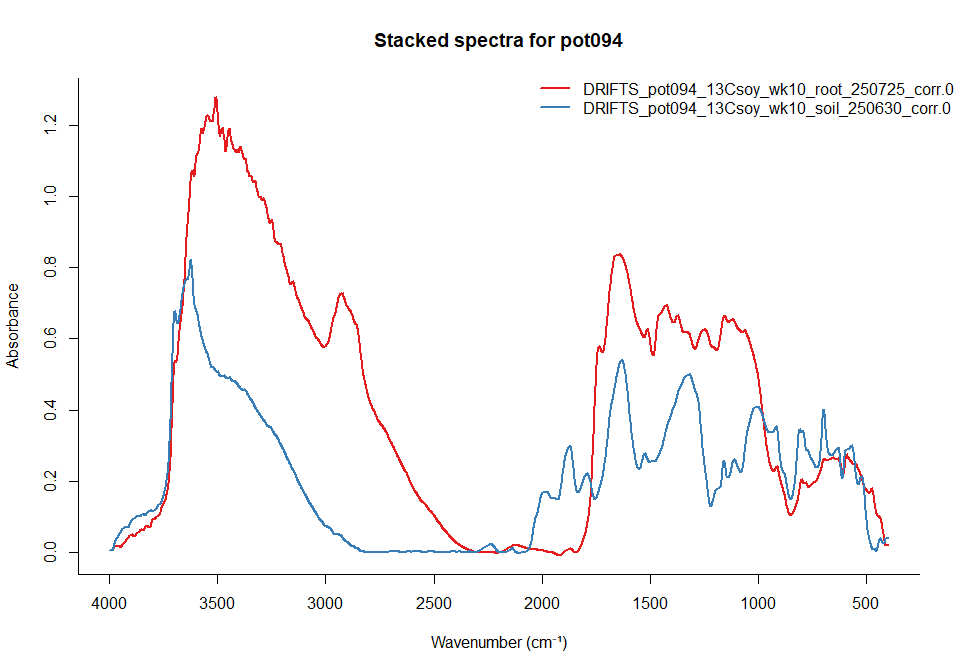

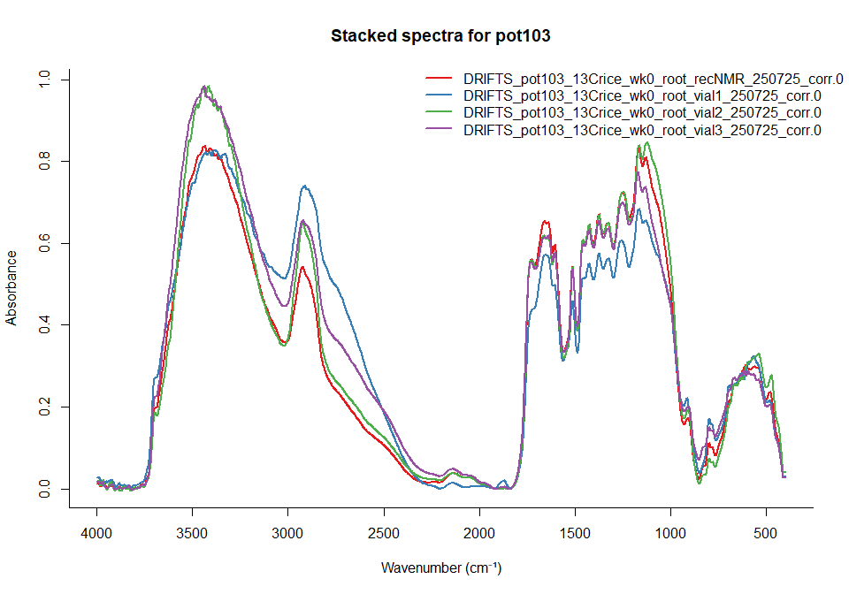

### Stacking by crop & time

This code stacks spectra of the same crop and timepoint

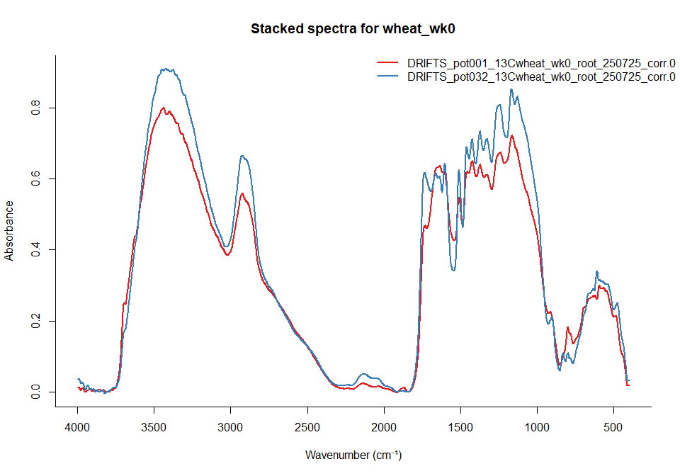

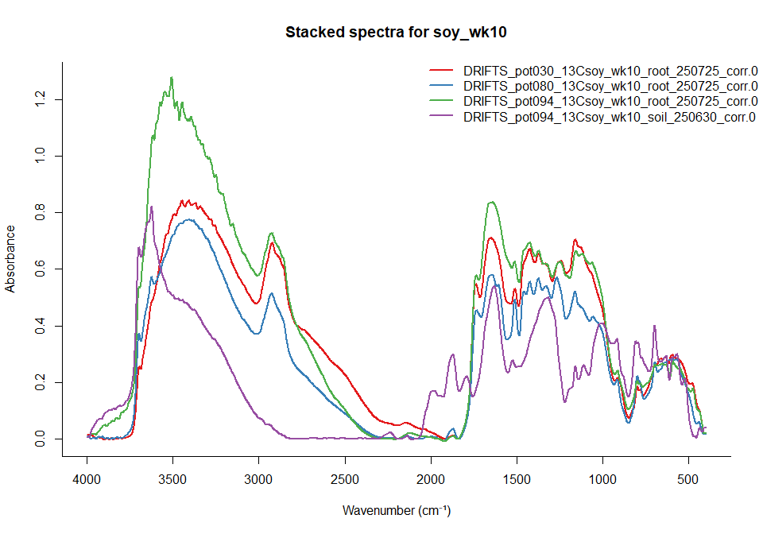

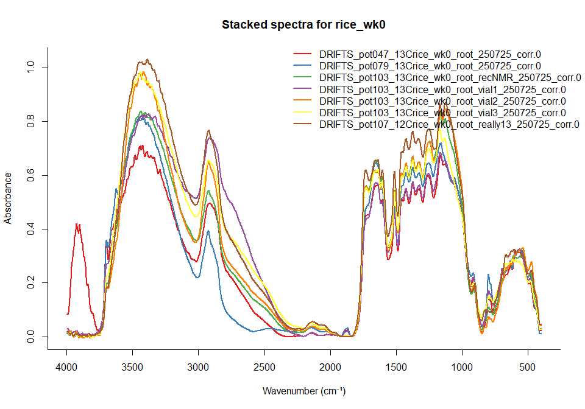

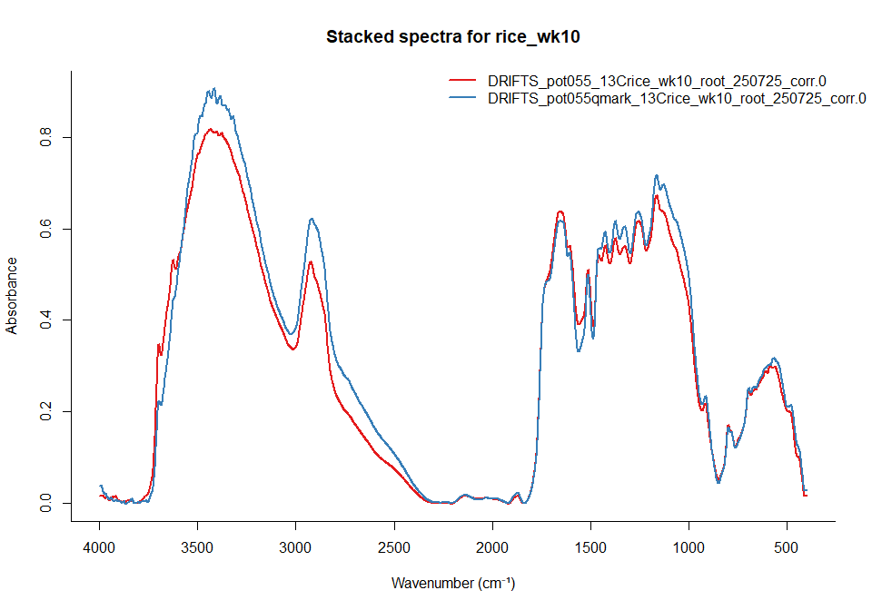

# Reading DPT files

Using data in the DPT format, we can normalize and visualize spectra across replicates, crops, and timepoints.

## Plotting by timepoint and sample type

### Week 0

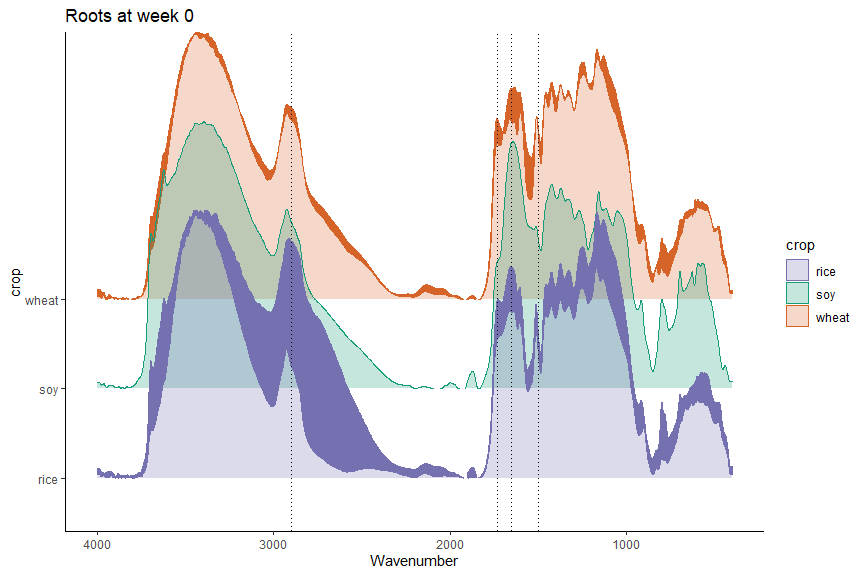

```
#> [1] "001" "032" "062" "079" "103" "107"
```

### Week 10

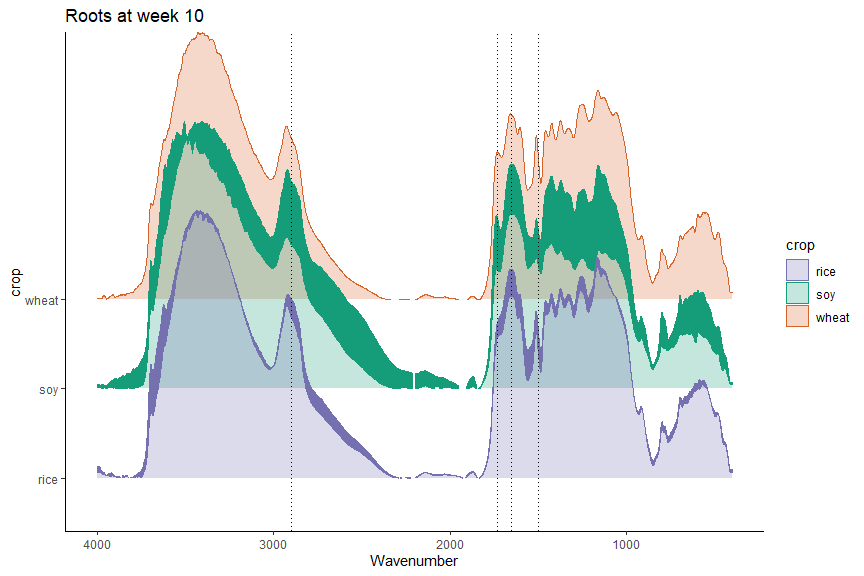

```
#> [1] "030"      "053"      "055"      "055qmark" "080"      "094"
```

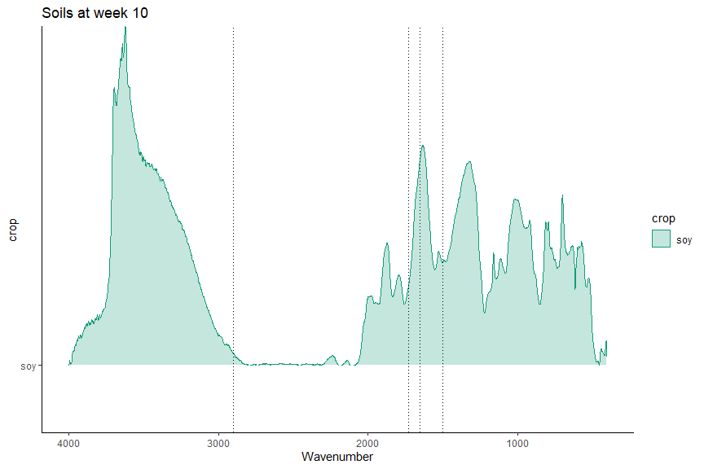

```
#> [1] "094"
```

### Plotting by crop

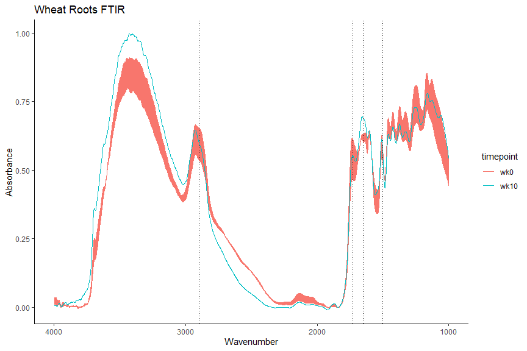

```
#> [1] "001" "032" "053"
```

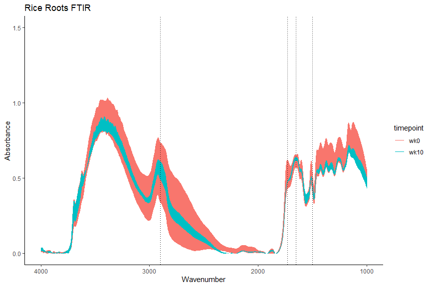

```
#> [1] "055"      "055qmark" "079"      "103"      "107"
```

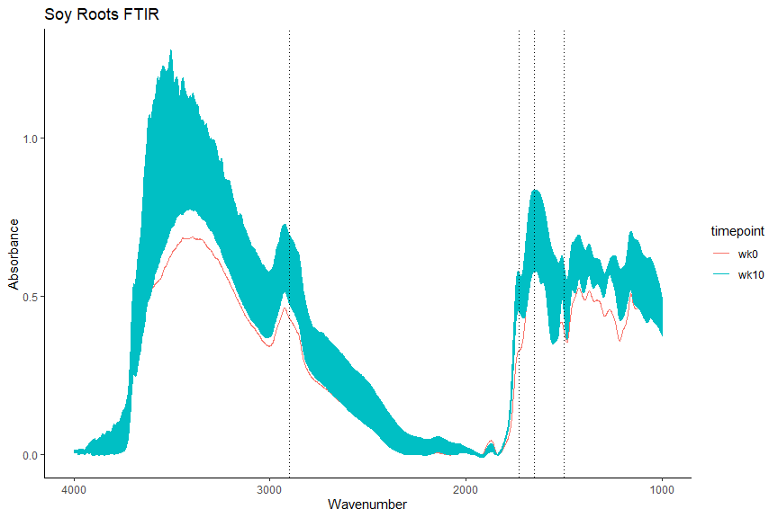

```
#> [1] "030" "062" "080" "094"
```